# Exercício Computacional 7

Importando libraries:

```r
library(tidyverse)
```

Setando o diretório corrente:

```r
setwd(dirname(rstudioapi::getActiveDocumentContext()$path))
getwd()
```

```
[1] "/Users/adrianosastre/Dropbox/Data Science/Exercícios/datascience-exercises-20200418-conceitos-ml/Exercícios-Computacionais/7"
```

Conceito explorado: MSE - Mean Square Error

Para que seja possível explorar e visualizar o impacto de n - realize, pelo menos, 1000 iterações do algoritmo. Especificamente, para cada valor do número de amostras avaliado, armazene e faça o cálculo da média aritmética sobre 1000 valores de performance, expressos pelo MSE. Um dica é aproveitar as estruturas em loop (for) do exercício anterior para a implementação das iterações.

1. Construa o modelo de geração de dados incluindo as iterações para cada valor de n

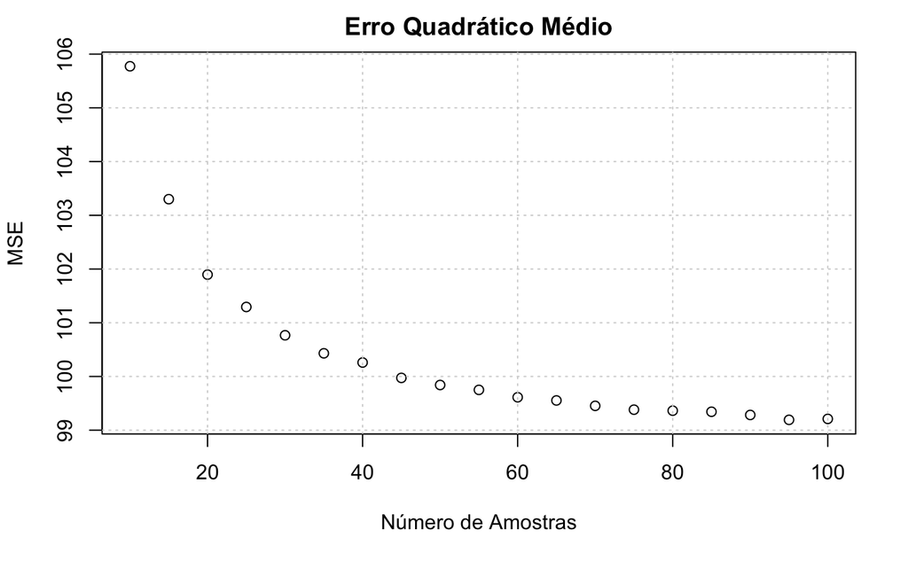

```r
# Número de iterações para cálculo do MSE
num_iter = 1000

# std_vector = seq(1,10,1)

# Vetor com valores de número de amostras
n_vector = seq(10,100,5)

# Inicialização dos vetores de MSE
MSE_vector = rep(0,length(n_vector))
MSE        = rep(0,num_iter)



for (k in 1:length(n_vector)){

  # Crie um vetor de índices x variando de 0 a 100. Utilize a função seq - sequence
  # x = seq(from = 0, to = 100, by = 1)
  n = n_vector[k]
  x = seq(1, 100, length.out = n)

  # Função hipótese verdadeira
  h_x <- 3*x + 30

  for (i in 1:num_iter){

    # Ruído
    std = 0.5
    epsilon <- rnorm(n, 0, std)

    # Variável de saída
    y <- h_x + epsilon


    # Função hipótese Estimada
    h_x_estimado <- 2.8*x + 32

    # Erro quadrático médio para uma iteração
    MSE[i] = (1/n)*sum(((y - h_x_estimado)^2))
  }


  # Erro quadrático médio para várias iterações
  MSE_vector[k] = mean(MSE)
}


# Visualização dos Resultados

# Usando o base plot system do R
plot(n_vector,MSE_vector,col=1, pch=1, main = 'Erro Quadrático Médio',
     col.main = 'black',
     xlab = 'Número de Amostras',
     ylab = 'MSE')
grid()
```

```r
# Usando o pacote ggplot2

# Criação de um dataframe a partir dos dados
data = data.frame(n_vector,MSE_vector)
```

2. Faça um gráfico que mostra o impacto de n, colocado sobre o eixo x, sobre o desempenho indicado pelo MSE, apresentado no eixo y.

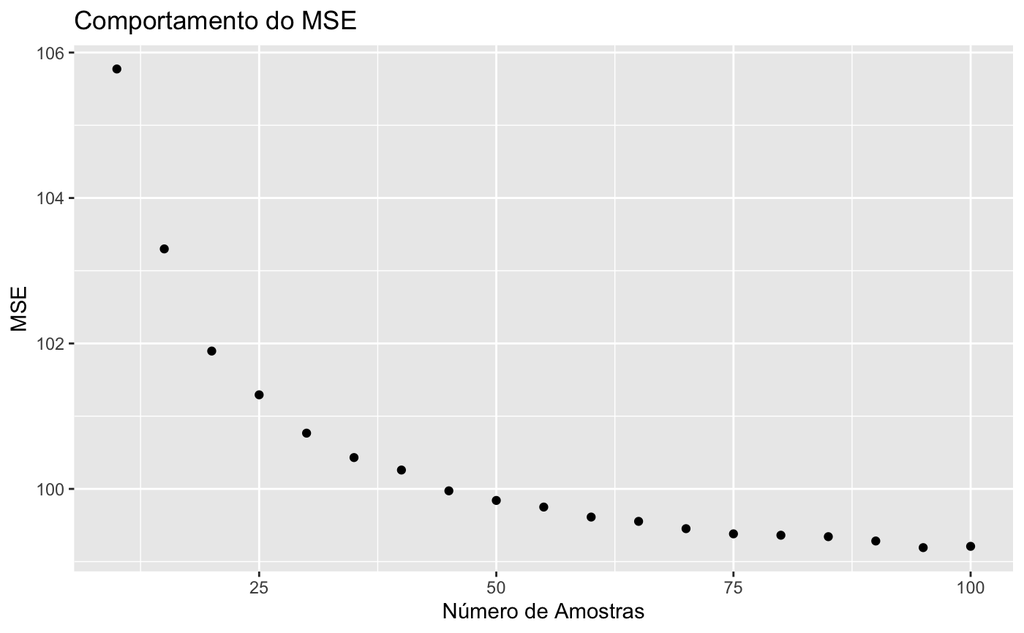

```r
# Uso do pipe (tidyverse) e ggplot2
data %>% ggplot(aes(x = n_vector, y = MSE_vector)) +
  geom_point() +
  xlab('Número de Amostras') +
  ylab('MSE') +
  ggtitle('Comportamento do MSE')
```

3. Faça uma análise: o impacto com o aumento ou redução de n é significativo para o modelo? Qual a justificativa?

RESPOSTA = A diferença entre o MSE_Teórico e o MSE_Empírico cai com o aumento do N